# Subtype: T / NK

T / NK 亚型。PCA 不含 TCR 基因，避免克隆型主导分群。

Level-1 `T/NK`。Scale / PCA / clustering **排除 TR 基因**，避免 TCR 克隆型主导分群。cluster 20 的混合在 subtype 里拆开。CellTypist 只作参考。

Subset 后重新 `NormalizeData`：细胞集合变了，HVG / PCA / Harmony 必须重做；丢掉全局 `scale.data` 后也需要从 counts 重建 `data`。

```r
pacman::p_load(Seurat, tidyverse, qs2, harmony, tictoc, cowplot, presto, SCpubr, scop)
knitr::opts_knit$set(root.dir = "/home/han/Desktop/guoqiang/stroke_bm/stroke_bm_Rproj")
setwd("/home/han/Desktop/guoqiang/stroke_bm/stroke_bm_Rproj")
source("codes/functions.R")
```

```r
res_path <- "results/subtype/tnk"
obj_path <- "data/rdata/subtype"
if (dir.exists(res_path)) {
  old_res <- list.files(res_path, full.names = TRUE)
  if (length(old_res) > 0) unlink(old_res, recursive = TRUE)
} else {
  dir.create(res_path, recursive = TRUE)
}
if (!dir.exists(obj_path)) dir.create(obj_path, recursive = TRUE)
```

```r
alpha <- .5
pt_size <- .5
raster <- FALSE
raster_dpi <- c(3000, 3000)
min_cutoff <- "q10"
max_cutoff <- "q90"
n_hvg <- 3000
```

```r
test_genes <- qs_read("data/rdata/test_genes.qs2", nthreads = 10)
seurat_object <-
  qs_read("data/rdata/seurat_object_first_annot.qs2", nthreads = 10)

table(seurat_object$annot)
```

```
          B         Ery        HSPC Mono/Mac/DC        Neut         pDC
       5201        6456        3705        5042       20978         570
     Plasma    Pre-Neut        T/NK
        780       13822       15792
```

```r
seurat_object <-
  subset(seurat_object, subset = annot %in% c("T/NK"))
dim(seurat_object)
```

```
[1] 38606 15792
```

```r
table(seurat_object$annot)
```

```
 T/NK
15792
```

```r
table(seurat_object$harmony_clusters_2)
```

```
   1    2    3    4    5    6    7    8    9   10   11   12   13   14   15   16
4118    0    0 3783    0    0 3132    0    0    0    0    0    0    0 2043    0
  17   18   19   20   21   22   23   24   25   26   27   28   29   30   31   32
   0    0    0 1520    0    0    0    0    0    0 1196    0    0    0    0    0
  33   34   35   36   37   38
   0    0    0    0    0    0
```

```r
if (length(Layers(seurat_object, search = "counts")) > 1) {
  seurat_object <- JoinLayers(seurat_object)
}
seurat_object[["RNA"]]$data <- NULL
seurat_object[["RNA"]]$scale.data <- NULL
DefaultLayer(seurat_object@assays$RNA)
```

```
[1] "counts"
```

```r
Layers(seurat_object)
```

```
[1] "counts"
```

### 1. Normalize, HVG, Scale, PCA

细胞集合变了，重新找高变基因和降维。PCA 肘图是在选后面用几个主成分，不是生物学结论。

```r
seurat_object <- NormalizeData(seurat_object, verbose = TRUE)
seurat_object <- FindVariableFeatures(
  seurat_object,
  nfeatures = n_hvg,
  verbose = TRUE
)
head(VariableFeatures(seurat_object), 20)
```

```
 [1] "CAMP"            "S100A8"          "S100A12"         "HBB"
 [5] "CCL4L2"          "LTF"             "HBA2"            "PTGDS"
 [9] "HBA1"            "LCN2"            "S100A9"          "DEFA3"
[13] "DEFA1"           "CCL4"            "TRBV7-2"         "ENSG00000227240"
[17] "MT1G"            "MT1E"            "TRBV10-3"        "HSPA6"
```

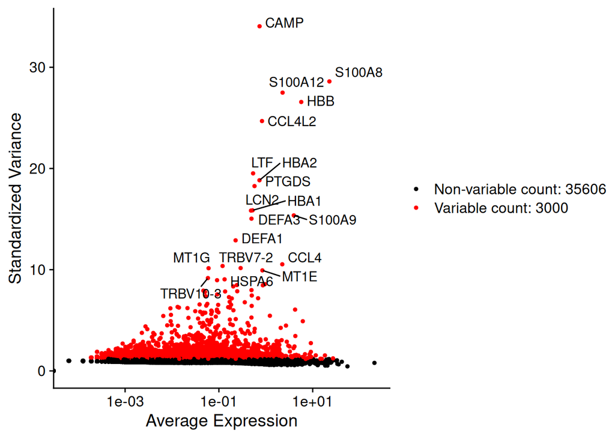

```r
LabelPoints(
  plot = VariableFeaturePlot(seurat_object),
  points = head(VariableFeatures(seurat_object), 20),
  repel = TRUE
)
```

```r
pca_features <- setdiff(
  VariableFeatures(seurat_object),
  test_genes$gene[test_genes$unwant | test_genes$tr]
)
sum(VariableFeatures(seurat_object) %in% test_genes$gene[test_genes$unwant])
```

```
[1] 35
```

```r
seurat_object <- ScaleData(
  seurat_object,
  features = pca_features,
  assay = "RNA"
)
seurat_object <- RunPCA(
  seurat_object,
  npcs = 50,
  features = pca_features,
  verbose = TRUE,
  reduction.name = "pca"
)
```

```r
num_pcs <- list()
num_pcs$pct <-
  seurat_object[["pca"]]@stdev / sum(seurat_object[["pca"]]@stdev) * 100
num_pcs$cumu <- cumsum(num_pcs$pct)
num_pcs$co1 <- which(num_pcs$cumu > 80 & num_pcs$pct < 5)[1]
num_pcs$co2 <- sort(
  which(
    (num_pcs$pct[seq_along(num_pcs$pct)[-length(num_pcs$pct)]] -
      num_pcs$pct[seq_along(num_pcs$pct)[-1]]) > 0.1
  ),
  decreasing = TRUE
)[1] + 1
num_pcs$pcs <- min(num_pcs$co1, num_pcs$co2)
num_pcs$co1
```

```
[1] 35
```

```r
num_pcs$co2
```

```
[1] 12
```

```r
num_pcs$pcs
```

```
[1] 12
```

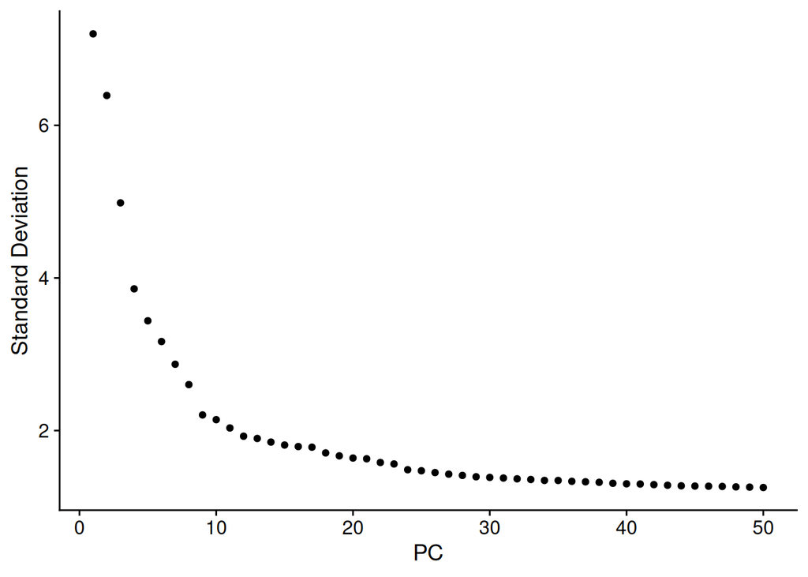

```r
ElbowPlot(seurat_object, reduction = "pca", ndims = 50)
```

### 2. Harmony

再按样本整合一次。看各样本是否混开。

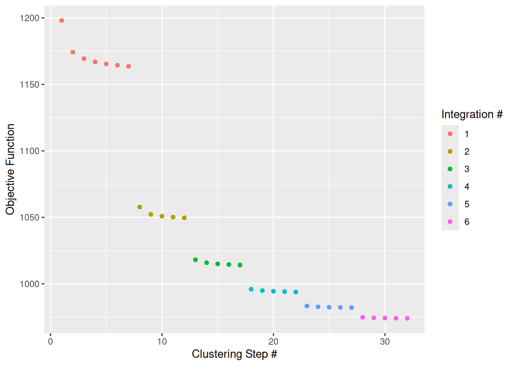

```r
tic("Harmony integration")
seurat_object <- RunHarmony(
  seurat_object,
  c("sample"),
  ncores = 15,
  plot_convergence = TRUE
)
```

```r
toc()
```

```
Harmony integration: 8.55 sec elapsed
```

```r
num_pcs <- list()
num_pcs$pct <-
  seurat_object[["harmony"]]@stdev /
  sum(seurat_object[["harmony"]]@stdev) * 100
num_pcs$cumu <- cumsum(num_pcs$pct)
num_pcs$co1 <- which(num_pcs$cumu > 90 & num_pcs$pct < 5)[1]
num_pcs$co2 <- sort(
  which(
    (num_pcs$pct[seq_along(num_pcs$pct)[-length(num_pcs$pct)]] -
      num_pcs$pct[seq_along(num_pcs$pct)[-1]]) > 0.1
  ),
  decreasing = TRUE
)[1] + 1
num_pcs$co1
```

```
[1] 43
```

```r
num_pcs$co2
```

```
[1] 24
```

```r
plot_harmony_umap <- function(obj, dims, file) {
  umap_temp <- RunUMAP(
    obj,
    dims = 1:dims,
    reduction = "harmony",
    reduction.name = "umap_harmony"
  )
  p <- plot_grid(
    ncol = 2,
    DimPlot(
      umap_temp, reduction = "umap_harmony", group.by = "sample",
      pt.size = pt_size, alpha = alpha, raster = raster, raster.dpi = raster_dpi
    ) + theme(aspect.ratio = 1),
    DimPlot(
      umap_temp, reduction = "umap_harmony", group.by = "group",
      pt.size = pt_size, alpha = alpha, raster = raster, raster.dpi = raster_dpi
    ) + theme(aspect.ratio = 1),
    DimPlot(
      umap_temp, reduction = "umap_harmony", group.by = "phase",
      pt.size = pt_size, alpha = alpha, raster = raster, raster.dpi = raster_dpi
    ) + theme(aspect.ratio = 1),
    DimPlot(
      umap_temp, reduction = "umap_harmony", group.by = "is_doublet",
      pt.size = pt_size, alpha = alpha, raster = raster, raster.dpi = raster_dpi
    ) + theme(aspect.ratio = 1)
  )
  ggsave(file, plot = p, width = 14, height = 12, dpi = 600)
  p
}
```

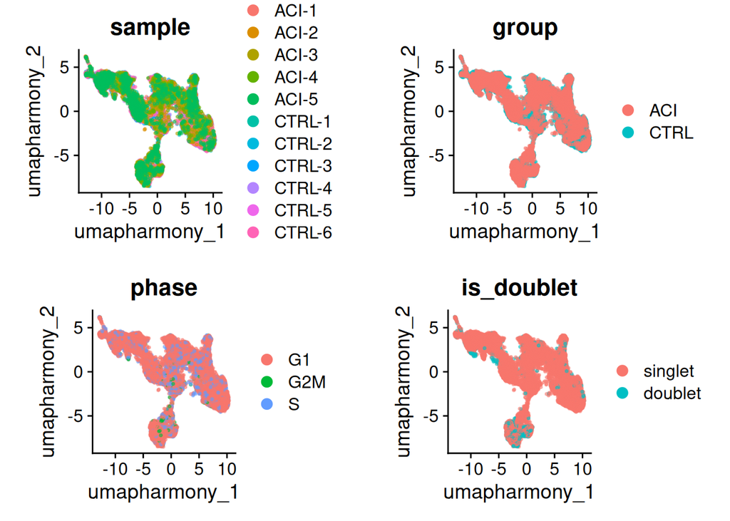

```r
plot_harmony_umap(seurat_object, 20, file.path(res_path, "01_dim_umap20.pdf"))
```

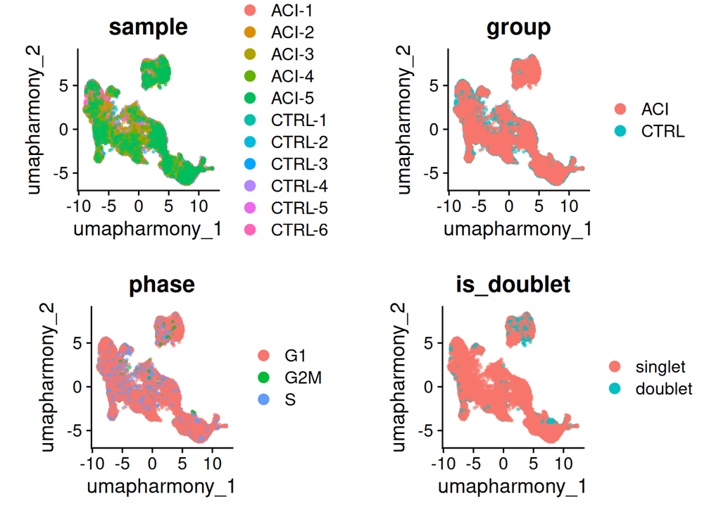

```r
plot_harmony_umap(seurat_object, 30, file.path(res_path, "01_dim_umap30.pdf"))
```

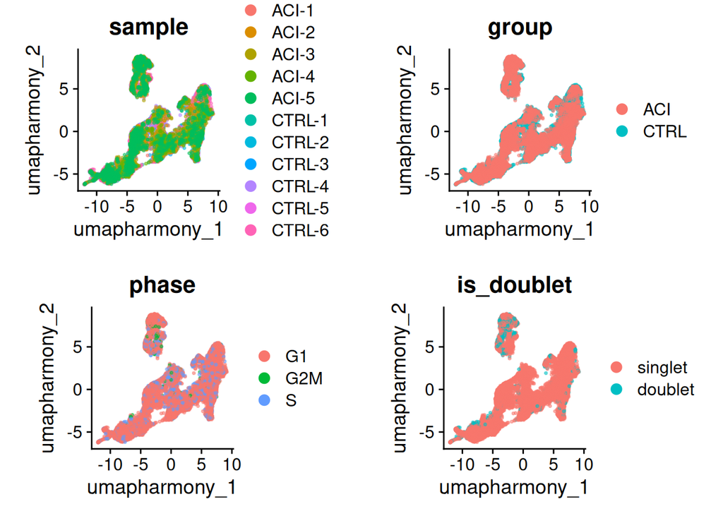

```r
plot_harmony_umap(seurat_object, 40, file.path(res_path, "01_dim_umap40.pdf"))
```

```r
# 看过 20/30/40 后改这里
n_dims <- 40
seurat_object <- RunUMAP(
  seurat_object,
  dims = 1:n_dims,
  reduction = "harmony",
  reduction.name = "umap_harmony"
)
```

### 3. Clustering

分辨率扫描。这里主要用于找低质量或明显混合的簇。

```r
seurat_object <- FindNeighbors(
  seurat_object,
  reduction = "harmony",
  dims = 1:n_dims
)
for (res in c(1, 2, 3, 4)) {
  print(res)
  set.seed(123)
  seurat_object <- FindClusters(
    seurat_object,
    cluster.name = paste0("harmony_clusters_", res),
    resolution = res,
    algorithm = 4
  )
  gc()
}
```

```
[1] 1
```

```
[1] 2
```

```
[1] 3
```

```
[1] 4
```

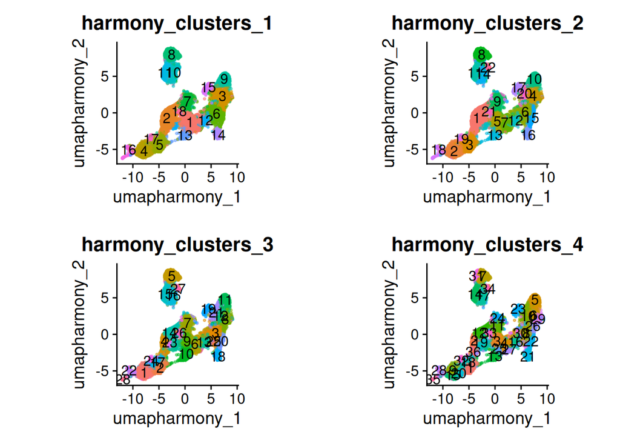

```r
plot_grid(
  ncol = 2,
  DimPlot(
    seurat_object, reduction = "umap_harmony",
    group.by = "harmony_clusters_1", label = TRUE,
    pt.size = pt_size, alpha = alpha, raster = raster, raster.dpi = raster_dpi
  ) + theme(aspect.ratio = 1) + NoLegend(),
  DimPlot(
    seurat_object, reduction = "umap_harmony",
    group.by = "harmony_clusters_2", label = TRUE,
    pt.size = pt_size, alpha = alpha, raster = raster, raster.dpi = raster_dpi
  ) + theme(aspect.ratio = 1) + NoLegend(),
  DimPlot(
    seurat_object, reduction = "umap_harmony",
    group.by = "harmony_clusters_3", label = TRUE,
    pt.size = pt_size, alpha = alpha, raster = raster, raster.dpi = raster_dpi
  ) + theme(aspect.ratio = 1) + NoLegend(),
  DimPlot(
    seurat_object, reduction = "umap_harmony",
    group.by = "harmony_clusters_4", label = TRUE,
    pt.size = pt_size, alpha = alpha, raster = raster, raster.dpi = raster_dpi
  ) + theme(aspect.ratio = 1) + NoLegend()
)
```

```r
ggsave(
  file.path(res_path, "02_qc_clusters.pdf"),
  width = 14, height = 18, dpi = 600
)
```

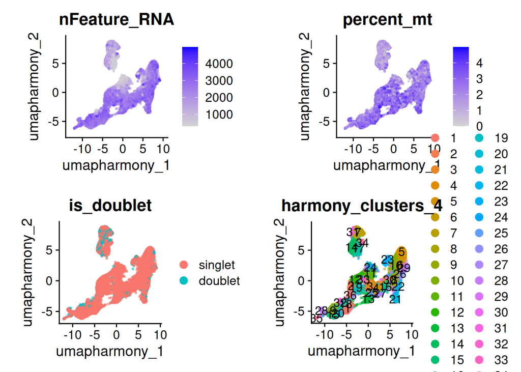

```r
plot_grid(
  ncol = 2,
  FeaturePlot(
    seurat_object, reduction = "umap_harmony", features = "nFeature_RNA",
    pt.size = pt_size, alpha = alpha, raster = raster, raster.dpi = raster_dpi
  ) + theme(aspect.ratio = 1),
  FeaturePlot(
    seurat_object, reduction = "umap_harmony", features = "percent_mt",
    pt.size = pt_size, alpha = alpha, raster = raster, raster.dpi = raster_dpi
  ) + theme(aspect.ratio = 1),
  DimPlot(
    seurat_object, reduction = "umap_harmony", group.by = "is_doublet",
    pt.size = pt_size, alpha = alpha, raster = raster, raster.dpi = raster_dpi
  ) + theme(aspect.ratio = 1),
  DimPlot(
    seurat_object, reduction = "umap_harmony",
    group.by = "harmony_clusters_4", label = TRUE,
    pt.size = pt_size, alpha = alpha, raster = raster, raster.dpi = raster_dpi
  ) + theme(aspect.ratio = 1)
)
```

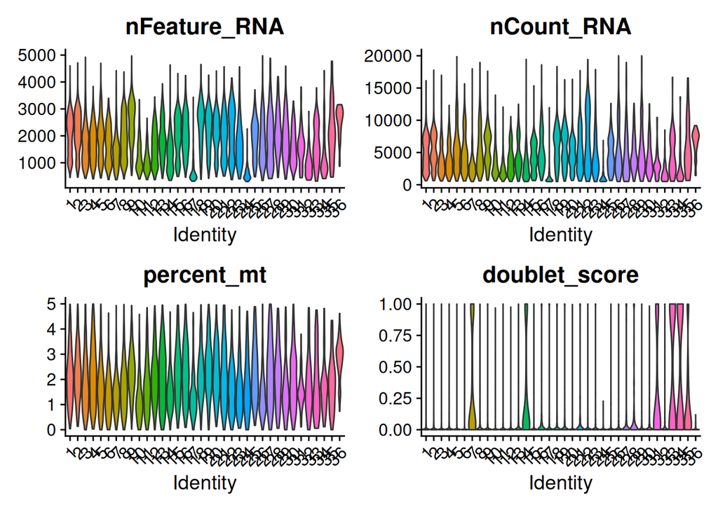

```r
Idents(seurat_object) <- "harmony_clusters_4"
VlnPlot(
  seurat_object,
  features = c("nFeature_RNA", "nCount_RNA", "percent_mt", "doublet_score"),
  ncol = 2, pt.size = 0
)
```

### 4. Markers

点图：点越大、颜色越深，表示该簇里越多细胞、表达越高。用来判断要不要丢掉某些簇。

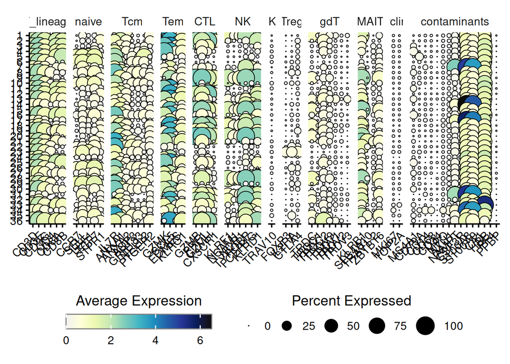

```r
marker_groups <- list(
  T_lineage = c("CD3D", "CD3E", "CD3G", "CD4", "CD8A", "CD8B"),
  naive = c("CCR7", "SELL", "LEF1", "TCF7", "S1PR1"),
  Tcm = c("IL7R", "ANXA1", "ANXA2", "AQP3", "GPR183", "NELL2", "PTGER2"),
  Tem = c("GZMK", "CCL5", "EOMES", "KLRG1"),
  CTL = c("GZMB", "PRF1", "GZMH", "CX3CR1"),
  NK = c("KLRF1", "NCAM1", "NCR1", "TYROBP", "FCER1G", "KLRD1"),
  NKT = c("TRAV10"),
  Treg = c("FOXP3", "IL2RA", "CTLA4"),
  gdT = c("TRDC", "TRGC1", "TRGC2", "TRGV9", "TRDV1", "TRDV2", "TRDV3"),
  MAIT = c("KLRB1", "SLC4A10", "TRAV1-2", "ZBTB16"),
  cycling = c("MKI67", "TOP2A"),
  contaminants = c(
    "MS4A1", "CD79A", "CD14", "CD68", "CD34", "MPO",
    "AZU1", "NAMPT", "CSF3R", "S100A8", "S100A9", "CA1", "HBB", "PF4", "PPBP"
  )
)

Idents(seurat_object) <- "harmony_clusters_4"
do_DotPlot(
  sample = seurat_object,
  flip = FALSE,
  legend.title = "Average Expression",
  legend.title.face = "plain",
  features = marker_groups,
  legend.length = 10
)
```

```r
ggsave(
  file.path(res_path, "02_qc_dotplot.pdf"),
  width = 16, height = 10, dpi = 600
)
```

```r
Idents(seurat_object) <- "harmony_clusters_4"
table(Idents(seurat_object))
```

```
  1   2   3   4   5   6   7   8   9  10  11  12  13  14  15  16  17  18  19  20
920 780 775 742 714 711 702 688 607 585 531 530 527 518 504 472 468 458 458 401
 21  22  23  24  25  26  27  28  29  30  31  32  33  34  35  36
378 343 342 335 313 295 280 262 254 234 185 178 106  90  54  52
```

```r
tnk_markers <- FindAllMarkers(seurat_object, only.pos = TRUE)

marker_table <-
  tnk_markers |>
  group_by(cluster) |>
  slice_head(n = 20) |>
  mutate(rank = paste0("Top_", row_number())) |>
  pivot_wider(id_cols = rank, names_from = cluster, values_from = gene)
marker_table
```

```
# A tibble: 20 × 37
   rank  `1`   `2`   `3`   `4`   `5`   `6`   `7`   `8`   `9`   `10`  `11`  `12`
   <chr> <chr> <chr> <chr> <chr> <chr> <chr> <chr> <chr> <chr> <chr> <chr> <chr>
 1 Top_1 FCGR… FGFB… GZMK  GZMK  NELL2 CCR7  MNDA  CD40… FCER… RPL32 GZMK  GZMH
 2 Top_2 GZMB  ENSG… HLA-… IFNG… LEF1  TSHZ2 NAMPT LINC… KLRF1 RPS12 RPL41 ZNF6…
 3 Top_3 KLRC2 ZNF6… CD74  CD27  CCR7  ANKR… CSF3R IL7R  FCGR… RPL30 RPS27 FGFB…
 4 Top_4 FGFB… GZMH  HLA-… CD8B  BACH2 RPL32 FCGR… CD4   CLIC3 RPL13 CD8A  CD52
 5 Top_5 GZMH  PRSS… HLA-… MS4A1 LINC… LEF1  FPR1  LTB   SPON2 RPS13 CCL5  B2M
 6 Top_6 GNLY  GZMB  CCL5  CD74  ACTN1 AK5   ACSL1 ENSG… IGFB… RPL11 CD74  NKG7
 7 Top_7 KLRC3 ZEB2  HLA-… CRTAM CD248 RPS13 S100… GPR1… SH2D… RPL10 B2M   SH3B…
 8 Top_8 KLRF1 ITGB1 HLA-… CD8A  PTPRK FHIT  IL1R2 VIM   NCR1  EEF1… IL32  GZMB
 9 Top_9 NKG7  CD8A  CD8A  ST8S… LRRN3 RPL30 RGS2  TIMP1 CHST2 RPS1… CD8B  HLA-C
10 Top_… TRDC  LINC… HLA-… DTHD1 ENSG… RPL11 G0S2  INPP… MYOM2 RPS2… RPS18 CCL5
11 Top_… KLRD1 LILR… CXCR6 CXCR6 NT5E  RPS8  BASP1 ANK3  AKR1… RPS8  RPS3  S100…
12 Top_… CST7  IL7   IL32  TOX   TRAB… RPS12 CMTM2 TNFR… LING… RPS28 RPS1… HLA-B
13 Top_… PRF1  NKG7  CD8B  DUSP2 CD8B  MAL   LST1  TPT1  L3MB… RPL39 RPL28 CD8A
14 Top_… ENSG… CX3C… GZMA  CCL5  CD79A RPS23 TREM1 IL2   DAB2  RPS23 EEF1… CX3C…
15 Top_… CX3C… MTSS1 HLA-… RGS1  AIF1  RPS14 RBM47 ADAM… PLXN… RPS5  RPL39 EFHD2
16 Top_… TYRO… ADGR… FABP5 THEM… ARMH1 RPL34 SPI1  AQP3  ZMAT4 RPL34 RPS12 TRGV4
17 Top_… ADGR… CD8B  HLA-… SH2D… REG4  RPL10 AQP9  LINC… LINC… RPL1… RPL13 CD3D
18 Top_… ENSG… C1or… PDCD1 CMC1  EPHA… RPL9  LRRK2 PLP2  GZMB  RPL19 RPS28 GNLY
19 Top_… PRSS… CD52  CCL4… CD3E  RPS13 RPL19 S100… CD52  CD38  RPL28 RPS25 CD99
20 Top_… KIR2… MYO3B HLA-A IL32  RPL32 RPL13 KCNJ… DPP4  GSAP  RPS4X HLA-B HLA-…
# ℹ 24 more variables: `13` <chr>, `14` <chr>, `15` <chr>, `16` <chr>,
#   `17` <chr>, `18` <chr>, `19` <chr>, `20` <chr>, `21` <chr>, `22` <chr>,
#   `23` <chr>, `24` <chr>, `25` <chr>, `26` <chr>, `27` <chr>, `28` <chr>,
#   `29` <chr>, `30` <chr>, `31` <chr>, `32` <chr>, `33` <chr>, `34` <chr>,
#   `35` <chr>, `36` <chr>
```

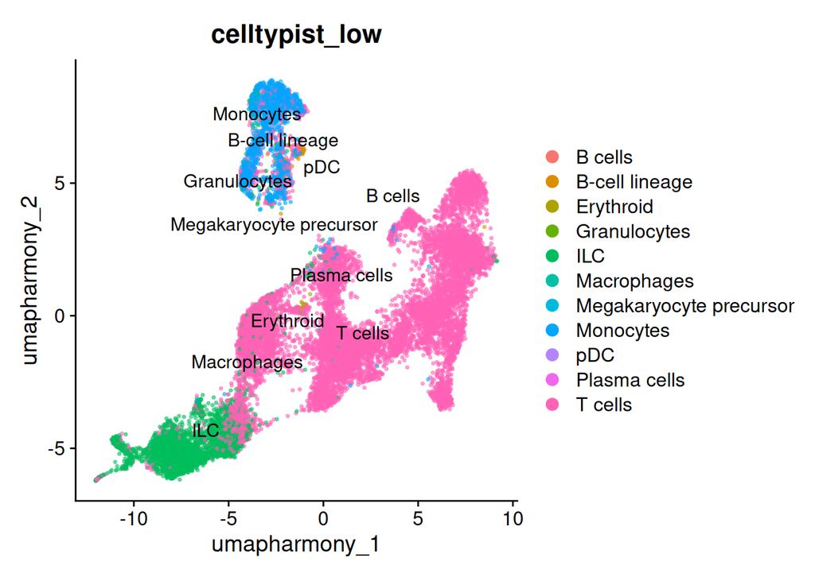

```r
pred_file <- "celltypist/predictions_low.tsv"
if (file.exists(pred_file)) {
  pred <- read_tsv(pred_file, show_col_types = FALSE)
  barcode_col <- names(pred)[1]
  pred_vec <- setNames(pred$majority_voting, pred[[barcode_col]])
  seurat_object$celltypist_low <-
    unname(pred_vec[colnames(seurat_object)])
  DimPlot(
    seurat_object,
    reduction = "umap_harmony",
    group.by = "celltypist_low",
    label = TRUE, repel = TRUE,
    pt.size = pt_size, alpha = alpha, raster = raster, raster.dpi = raster_dpi
  ) + theme(aspect.ratio = 1)
}
```

### 5. Round 2 (optional)

去掉低质量或混合簇后重新降维。

按 QC 和 marker 去掉低质量或混合簇，再从 counts 重新 Normalize、高变基因、PCA、Harmony 和聚类。

```r
drop_clusters <- c(7, 14, 17, 31, 32, 33, 34, 35)
# drop_clusters <- c("3", "7")
```

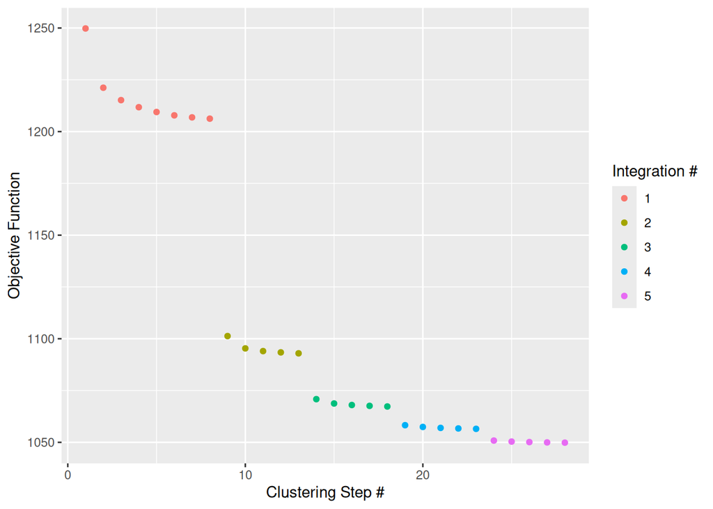

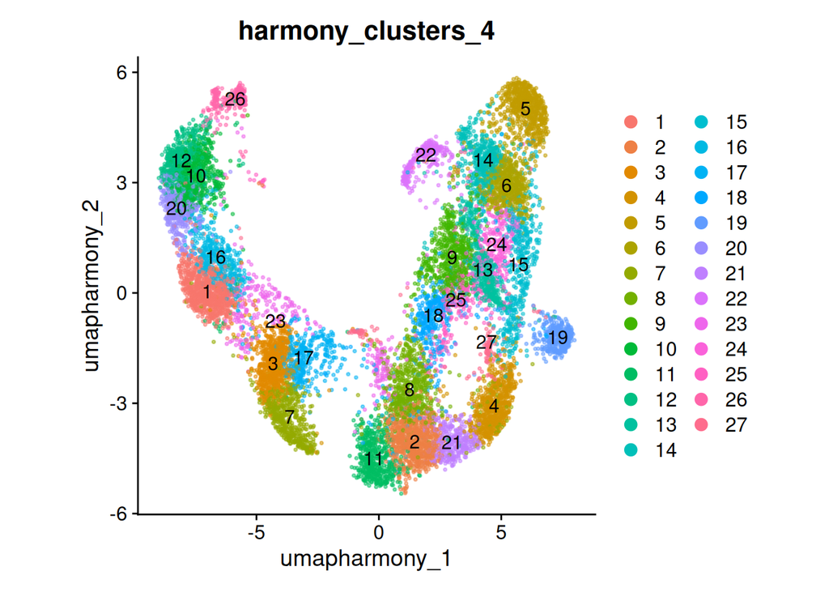

```r
if (length(drop_clusters) == 0) {
  message("No clusters listed to drop; skip round 2.")
} else {
  n_before <- ncol(seurat_object)
  keep_cells <- colnames(seurat_object)[
    !(as.character(seurat_object$harmony_clusters_4) %in%
      as.character(drop_clusters))
  ]
  seurat_object <- subset(seurat_object, cells = keep_cells)
  message(
    sprintf("Dropped %s cells; %s remain.", n_before - ncol(seurat_object), ncol(seurat_object))
  )

  Idents(seurat_object) <- "sample"
  drop_cols <- grep(
    "^harmony_clusters_|^seurat_clusters$",
    colnames(seurat_object[[]]),
    value = TRUE
  )
  seurat_object@meta.data <-
    seurat_object@meta.data[, setdiff(colnames(seurat_object[[]]), drop_cols), drop = FALSE]

  seurat_object[["RNA"]]$data <- NULL
  seurat_object[["RNA"]]$scale.data <- NULL
  seurat_object <- NormalizeData(seurat_object, verbose = TRUE)
  seurat_object <- FindVariableFeatures(
    seurat_object, nfeatures = n_hvg, verbose = TRUE
  )
  pca_features <- setdiff(
    VariableFeatures(seurat_object),
    test_genes$gene[test_genes$unwant | test_genes$tr]
  )
  seurat_object <- ScaleData(seurat_object, features = pca_features, assay = "RNA")
  seurat_object <- RunPCA(
    seurat_object, npcs = 50, features = pca_features,
    verbose = TRUE, reduction.name = "pca"
  )
  seurat_object <- RunHarmony(
    seurat_object, c("sample"), ncores = 15, plot_convergence = TRUE
  )
  seurat_object <- RunUMAP(
    seurat_object, dims = 1:n_dims, reduction = "harmony",
    reduction.name = "umap_harmony"
  )
  seurat_object <- FindNeighbors(
    seurat_object, reduction = "harmony", dims = 1:n_dims
  )
  for (res in c(1, 2, 3, 4)) {
    set.seed(123)
    seurat_object <- FindClusters(
      seurat_object,
      cluster.name = paste0("harmony_clusters_", res),
      resolution = res,
      algorithm = 4
    )
  }
  DimPlot(
    seurat_object, reduction = "umap_harmony",
    group.by = "harmony_clusters_4", label = TRUE,
    pt.size = pt_size, alpha = alpha, raster = raster, raster.dpi = raster_dpi
  ) + theme(aspect.ratio = 1)
}
```

### 5b. Check cleanup

检查清理后 UMAP 是否还剩明显的垃圾团或双细胞团。

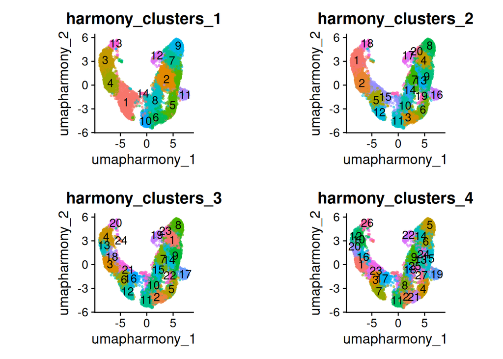

```r
plot_grid(
  ncol = 2,
  DimPlot(
    seurat_object, reduction = "umap_harmony",
    group.by = "harmony_clusters_1", label = TRUE,
    pt.size = pt_size, alpha = alpha, raster = raster, raster.dpi = raster_dpi
  ) + theme(aspect.ratio = 1) + NoLegend(),
  DimPlot(
    seurat_object, reduction = "umap_harmony",
    group.by = "harmony_clusters_2", label = TRUE,
    pt.size = pt_size, alpha = alpha, raster = raster, raster.dpi = raster_dpi
  ) + theme(aspect.ratio = 1) + NoLegend(),
  DimPlot(
    seurat_object, reduction = "umap_harmony",
    group.by = "harmony_clusters_3", label = TRUE,
    pt.size = pt_size, alpha = alpha, raster = raster, raster.dpi = raster_dpi
  ) + theme(aspect.ratio = 1) + NoLegend(),
  DimPlot(
    seurat_object, reduction = "umap_harmony",
    group.by = "harmony_clusters_4", label = TRUE,
    pt.size = pt_size, alpha = alpha, raster = raster, raster.dpi = raster_dpi
  ) + theme(aspect.ratio = 1) + NoLegend()
)
```

```r
ggsave(
  file.path(res_path, "03_postqc_clusters.pdf"),
  width = 14, height = 12, dpi = 600
)
```

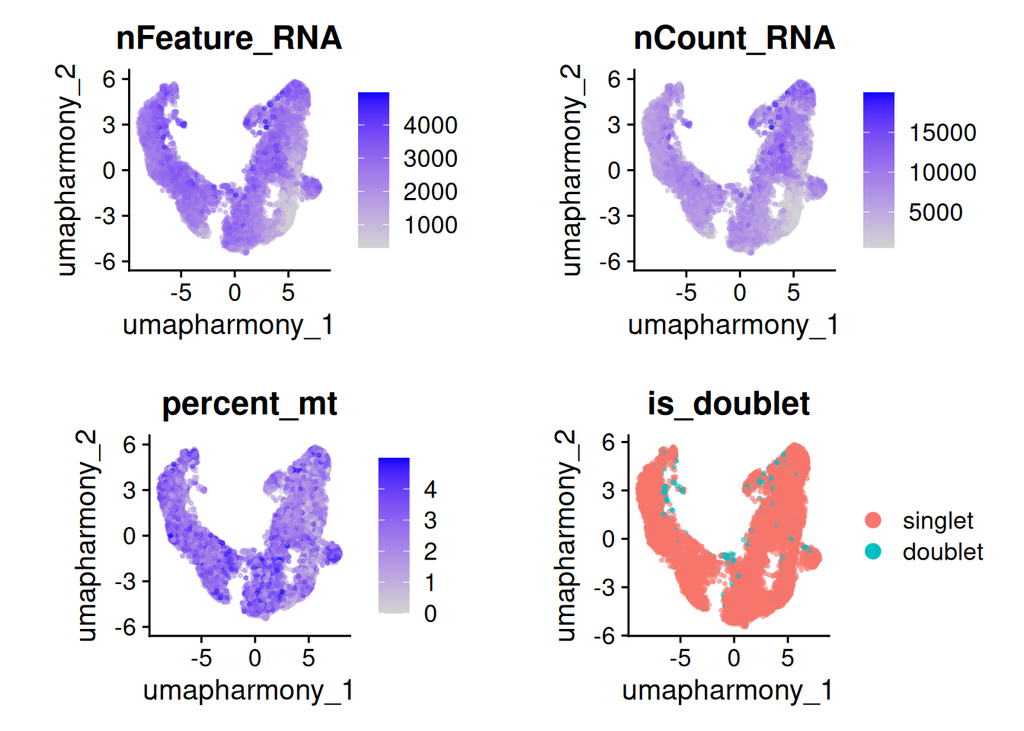

```r
plot_grid(
  ncol = 2,
  FeaturePlot(
    seurat_object, reduction = "umap_harmony", features = "nFeature_RNA",
    pt.size = pt_size, alpha = alpha, raster = raster, raster.dpi = raster_dpi
  ) + theme(aspect.ratio = 1),
  FeaturePlot(
    seurat_object, reduction = "umap_harmony", features = "nCount_RNA",
    pt.size = pt_size, alpha = alpha, raster = raster, raster.dpi = raster_dpi
  ) + theme(aspect.ratio = 1),
  FeaturePlot(
    seurat_object, reduction = "umap_harmony", features = "percent_mt",
    pt.size = pt_size, alpha = alpha, raster = raster, raster.dpi = raster_dpi
  ) + theme(aspect.ratio = 1),
  DimPlot(
    seurat_object, reduction = "umap_harmony", group.by = "is_doublet",
    pt.size = pt_size, alpha = alpha, raster = raster, raster.dpi = raster_dpi
  ) + theme(aspect.ratio = 1)
)
```

```r
ggsave(
  file.path(res_path, "03_postqc_metrics.pdf"),
  width = 14, height = 12, dpi = 600
)
```

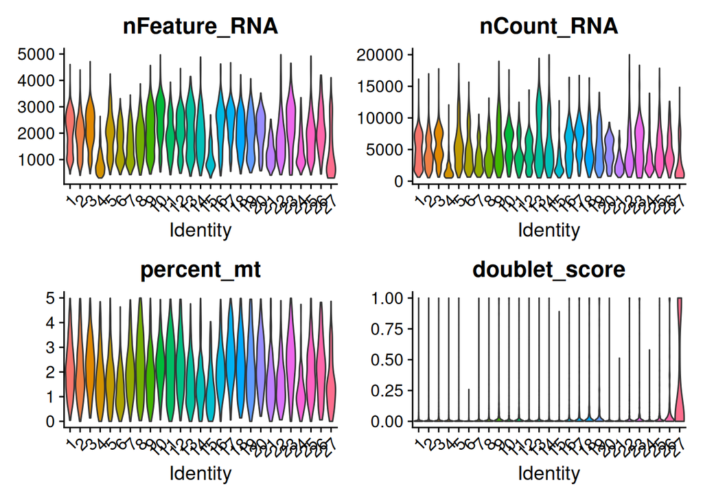

```r
Idents(seurat_object) <- "harmony_clusters_4"
VlnPlot(
  seurat_object,
  features = c("nFeature_RNA", "nCount_RNA", "percent_mt", "doublet_score"),
  ncol = 2, pt.size = 0
)
```

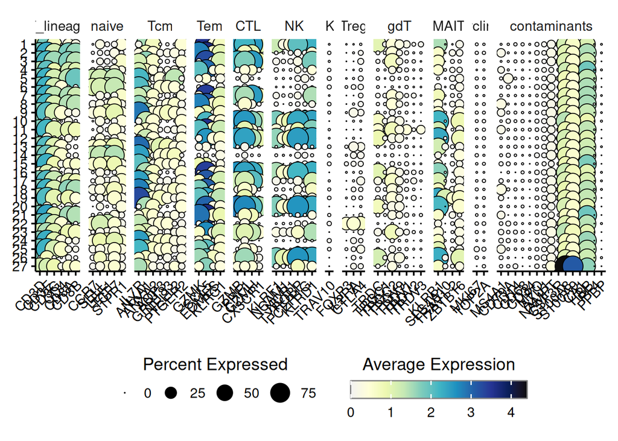

```r
Idents(seurat_object) <- "harmony_clusters_4"
do_DotPlot(
  sample = seurat_object,
  flip = FALSE,
  legend.title = "Average Expression",
  legend.title.face = "plain",
  features = marker_groups,
  legend.length = 10
)
```

```r
ggsave(
  file.path(res_path, "03_postqc_dotplot.pdf"),
  width = 16, height = 8, dpi = 600
)
```

若仍有低质量簇，记下当前高分辨率 ID，下一节 subset 后重跑降维。

```r
drop_clusters_r3 <- c(27)
# drop_clusters_r3 <- c("2", "5")
```

```r
if (length(drop_clusters_r3) == 0) {
  message("No extra clusters to drop.")
} else {
  n_before <- ncol(seurat_object)
  keep_cells <- colnames(seurat_object)[
    !(as.character(seurat_object$harmony_clusters_4) %in%
      as.character(drop_clusters_r3))
  ]
  seurat_object <- subset(seurat_object, cells = keep_cells)
  message(
    sprintf("Dropped %s cells; %s remain.", n_before - ncol(seurat_object), ncol(seurat_object))
  )
}
```

### 6. Recluster for annotation

用清理后的细胞重新聚类，供最后命名。

用清理后的细胞做最终降维，并在 0.1 / 0.2 / 0.5 / 1 分辨率下聚类，供命名。

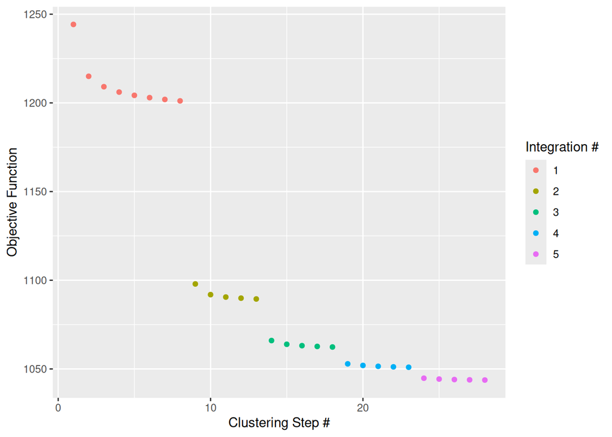

```r
Idents(seurat_object) <- "sample"
drop_cols <- grep(
  "^harmony_clusters_|^seurat_clusters$",
  colnames(seurat_object[[]]),
  value = TRUE
)
if (length(drop_cols) > 0) {
  seurat_object@meta.data <-
    seurat_object@meta.data[, setdiff(colnames(seurat_object[[]]), drop_cols), drop = FALSE]
}

seurat_object[["RNA"]]$data <- NULL
seurat_object[["RNA"]]$scale.data <- NULL
seurat_object <- NormalizeData(seurat_object, verbose = TRUE)
seurat_object <- FindVariableFeatures(
  seurat_object, nfeatures = n_hvg, verbose = TRUE
)
pca_features <- setdiff(
  VariableFeatures(seurat_object),
  test_genes$gene[test_genes$unwant | test_genes$tr]
)
seurat_object <- ScaleData(seurat_object, features = pca_features, assay = "RNA")
seurat_object <- RunPCA(
  seurat_object, npcs = 50, features = pca_features,
  verbose = TRUE, reduction.name = "pca"
)
tic("Harmony integration")
seurat_object <- RunHarmony(
  seurat_object, c("sample"), ncores = 15, plot_convergence = TRUE
)
```

```r
toc()
```

```
Harmony integration: 6.873 sec elapsed
```

```r
seurat_object <- RunUMAP(
  seurat_object, dims = 1:20, reduction = "harmony",
  reduction.name = "umap"
)
seurat_object <- FindNeighbors(
  seurat_object, reduction = "harmony", dims = 1:20
)
for (res in c(0.1, 0.2, 0.5, 1)) {
  print(res)
  set.seed(123)
  seurat_object <- FindClusters(
    seurat_object,
    cluster.name = paste0("harmony_clusters_", res),
    resolution = res,
    algorithm = 4
  )
  gc()
}
```

```
[1] 0.1
```

```
[1] 0.2
```

```
[1] 0.5
```

```
[1] 1
```

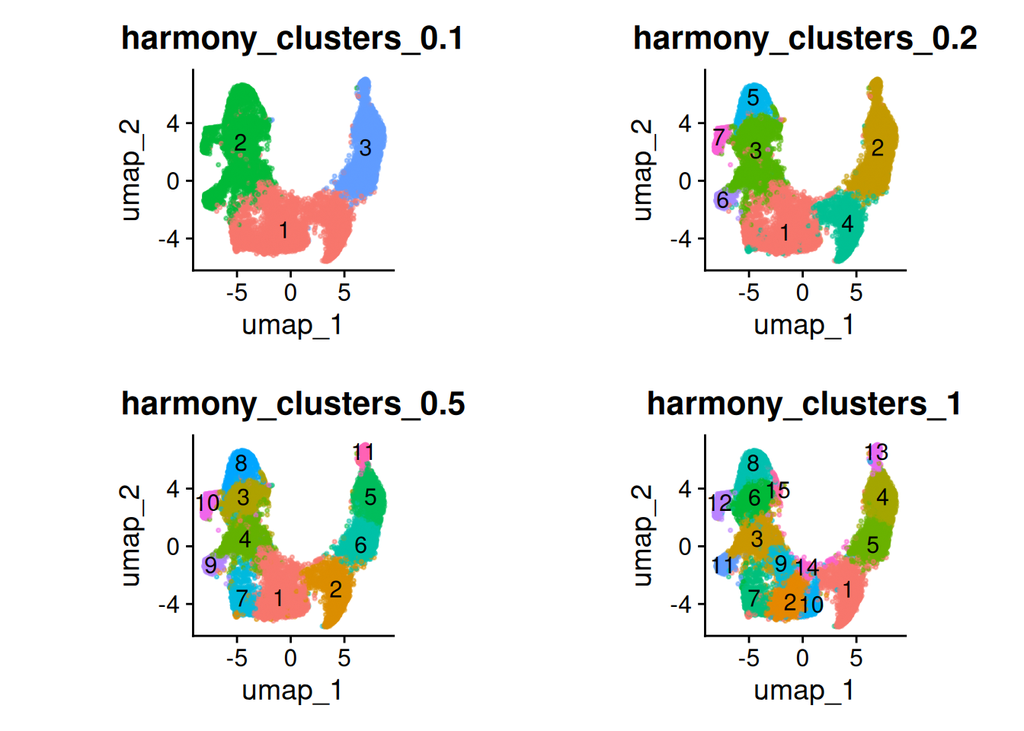

```r
plot_grid(
  ncol = 2,
  DimPlot(
    seurat_object, reduction = "umap",
    group.by = "harmony_clusters_0.1", label = TRUE,
    pt.size = pt_size, alpha = alpha, raster = raster, raster.dpi = raster_dpi
  ) + theme(aspect.ratio = 1) + NoLegend(),
  DimPlot(
    seurat_object, reduction = "umap",
    group.by = "harmony_clusters_0.2", label = TRUE,
    pt.size = pt_size, alpha = alpha, raster = raster, raster.dpi = raster_dpi
  ) + theme(aspect.ratio = 1) + NoLegend(),
  DimPlot(
    seurat_object, reduction = "umap",
    group.by = "harmony_clusters_0.5", label = TRUE,
    pt.size = pt_size, alpha = alpha, raster = raster, raster.dpi = raster_dpi
  ) + theme(aspect.ratio = 1) + NoLegend(),
  DimPlot(
    seurat_object, reduction = "umap",
    group.by = "harmony_clusters_1", label = TRUE,
    pt.size = pt_size, alpha = alpha, raster = raster, raster.dpi = raster_dpi
  ) + theme(aspect.ratio = 1) + NoLegend()
)
```

```r
ggsave(
  file.path(res_path, "04_recluster.pdf"),
  width = 14, height = 12, dpi = 600
)
```

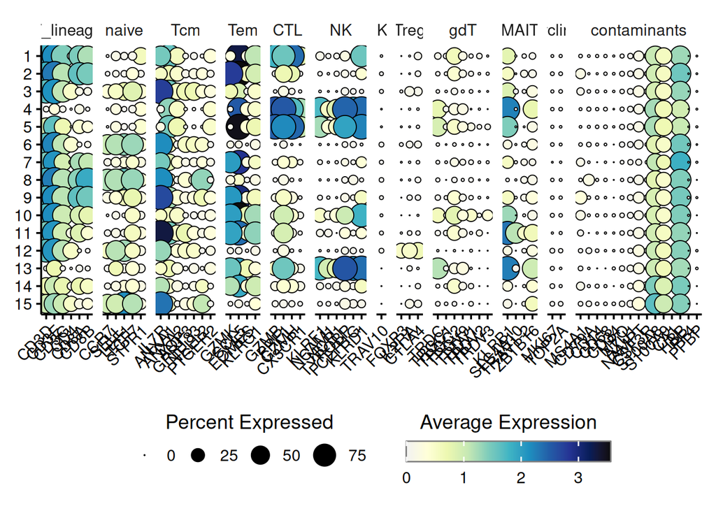

```r
Idents(seurat_object) <- "harmony_clusters_1"
do_DotPlot(
  sample = seurat_object,
  flip = FALSE,
  legend.title = "Average Expression",
  legend.title.face = "plain",
  features = marker_groups,
  legend.length = 10
)
```

```r
# 改 ident.1 为要检查是否该拆开的 cluster
FindMarkers(
  seurat_object,
  group.by = "harmony_clusters_1",
  ident.1 = 2,
  only.pos = TRUE
) |>
  head(n = 20)
```

```
                 p_val avg_log2FC pct.1 pct.2     p_val_adj
GZMK      0.000000e+00  2.4497524 0.952 0.266  0.000000e+00
HLA-DRB1  0.000000e+00  1.7047339 0.802 0.386  0.000000e+00
HLA-DQA1  0.000000e+00  2.6304833 0.424 0.089  0.000000e+00
CD74      0.000000e+00  1.9465836 0.966 0.724  0.000000e+00
CCL5     1.044007e-307  1.0687538 0.986 0.668 4.030492e-303
CD8A     7.278640e-279  1.3892160 0.769 0.347 2.809992e-274
HLA-DRA  5.398178e-271  2.2209343 0.501 0.157 2.084020e-266
CD8B     4.056125e-255  1.3479243 0.723 0.304 1.565907e-250
CXCR6    1.072029e-249  2.4453465 0.338 0.073 4.138673e-245
RGS1     1.281383e-237  2.7427709 0.355 0.089 4.946906e-233
HLA-DPA1 1.798370e-217  1.3826376 0.739 0.424 6.942788e-213
GZMA     5.835397e-213  0.9394927 0.935 0.621 2.252813e-208
CCL4     4.315507e-202  1.3759568 0.786 0.445 1.666045e-197
HLA-DQB1 1.279999e-197  2.0160291 0.436 0.150 4.941566e-193
IL32     3.261859e-194  0.7535600 0.985 0.881 1.259273e-189
TOX      1.641898e-184  1.3542258 0.685 0.372 6.338713e-180
CCL4L2   1.708478e-171  1.9419823 0.451 0.177 6.595751e-167
HLA-DPB1 1.211048e-162  1.1243969 0.752 0.481 4.675372e-158
CRTAM    7.251603e-162  1.8135436 0.366 0.122 2.799554e-157
HLA-DRB5 2.983583e-149  1.9783226 0.325 0.104 1.151842e-144
```

### 7. Markers for annotation

命名用的 marker 点图。对照教科书基因，给每个簇起亚型名。

先分 lineage，再分状态。Scale/PCA 已排除 TR；`TRAV1-2` / `TRAV10` 只用来看，不进 PCA。

**Naive / Tcm / Tem / CTL**（先看 CD4 vs CD8，再套这套）：

1. **Naive**：`LEF1` `TCF7` `CCR7` `SELL` 高，颗粒酶全无。
2. **Tcm**：淋巴归巢还在（FeaturePlot 对照 `CCR7`/`SELL`），`LEF1` 不如 naive 齐，有 `IL7R` `ANXA1` `ANXA2` `AQP3` `GPR183`；CD8 再看 `NELL2`。**没有 `GZMK`/`GZMB`**。和 naive 糊在一起就并成 naive/Tcm。
3. **Tem**：归巢掉，**`GZMK+` `CCL5+`**，`GZMB` 还不高。
4. **CTL**：`GZMB` `PRF1` `GZMH` `CX3CR1` 高，`GZMK` 往往下来。CD8 最清楚；CD4 CTL 少但分子一样。

**NK vs NKT / NKT-like**：

- **NK**：`CD3-`（`CD3D/E/G` 基本无），`KLRF1` `NCAM1` `NCR1` `TYROBP` `FCER1G` 高。
- **iNKT（真 NKT）**：`CD3+`，**`TRAV10`**（Vα24），可有 `ZBTB16`；人骨髓里很少。和 MAIT 的差别是 MAIT 用 `TRAV1-2`/`SLC4A10`，不是 `TRAV10`。
- **CD8 NKT-like**（旧稿里的 Tem/NK-like、CTL/NK-like）：`CD3+` `CD8+`，又带 NK 受体，但 **`KLRF1`/`NCAM1`/`TYROBP` 不如真 NK**。这是常规 CD8，不是 iNKT；不要只靠 `NKG7`/`GNLY`/`FGFBP2`（CTL 也有）。

DotPlot 的 `marker_groups` 每个基因只出现一次。FeaturePlot 仍可对照共用分子（如 Tcm 图里的 `CCR7`）。

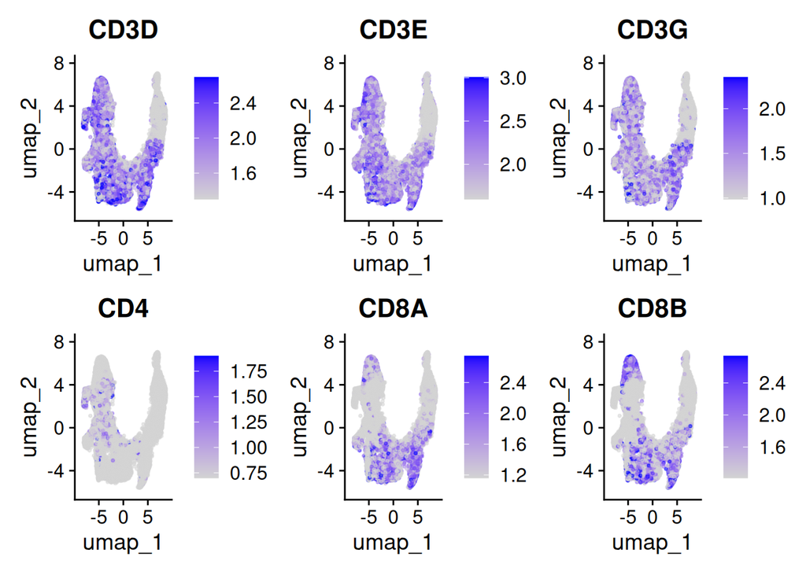

```r
FeaturePlot(
  seurat_object, reduction = "umap", ncol = 3,
  min.cutoff = min_cutoff, max.cutoff = max_cutoff,
  features = c("CD3D", "CD3E", "CD3G", "CD4", "CD8A", "CD8B"),
  pt.size = pt_size, alpha = alpha, raster = raster, raster.dpi = raster_dpi
)
```

```r
ggsave(file.path(res_path, "05_markers_T.pdf"), width = 18, height = 10)
```

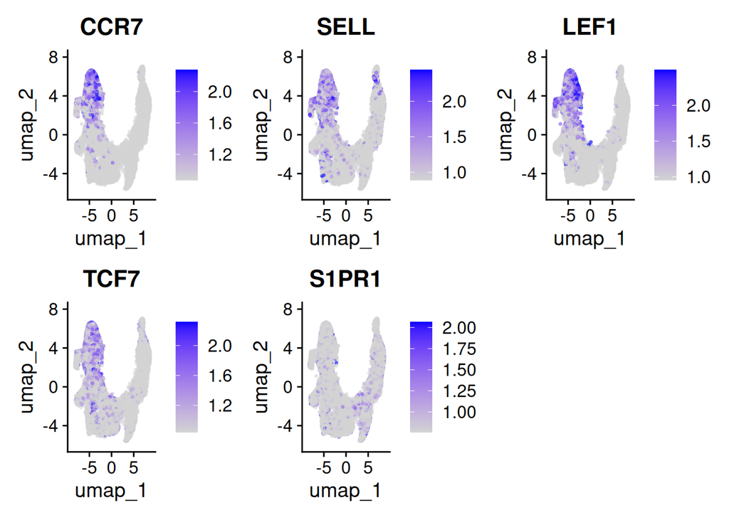

```r
FeaturePlot(
  seurat_object, reduction = "umap", ncol = 3,
  min.cutoff = min_cutoff, max.cutoff = max_cutoff,
  features = c("CCR7", "SELL", "LEF1", "TCF7", "S1PR1"),
  pt.size = pt_size, alpha = alpha, raster = raster, raster.dpi = raster_dpi
)
```

```r
ggsave(file.path(res_path, "05_markers_naive.pdf"), width = 18, height = 10)
```

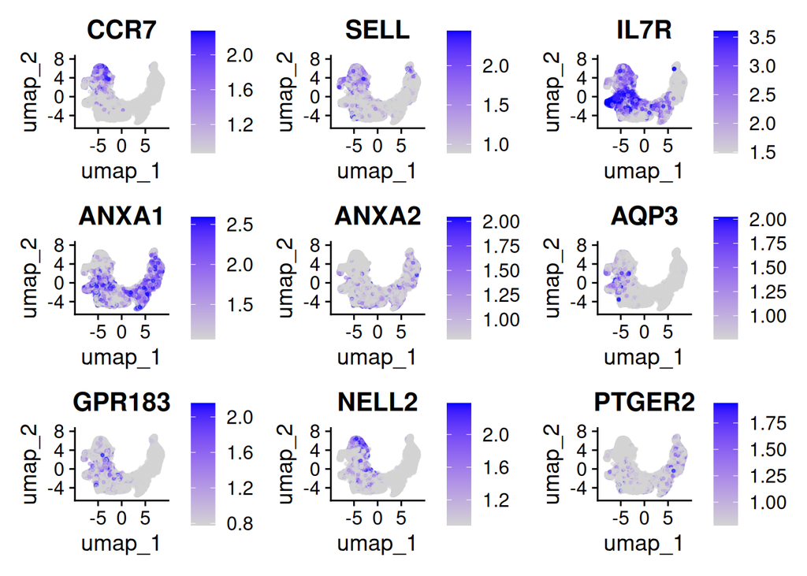

```r
FeaturePlot(
  seurat_object, reduction = "umap", ncol = 3,
  min.cutoff = min_cutoff, max.cutoff = max_cutoff,
  features = c(
    "CCR7", "SELL", "IL7R", "ANXA1", "ANXA2",
    "AQP3", "GPR183", "NELL2", "PTGER2"
  ),
  pt.size = pt_size, alpha = alpha, raster = raster, raster.dpi = raster_dpi
)
```

```r
ggsave(file.path(res_path, "05_markers_Tcm.pdf"), width = 18, height = 15)
```

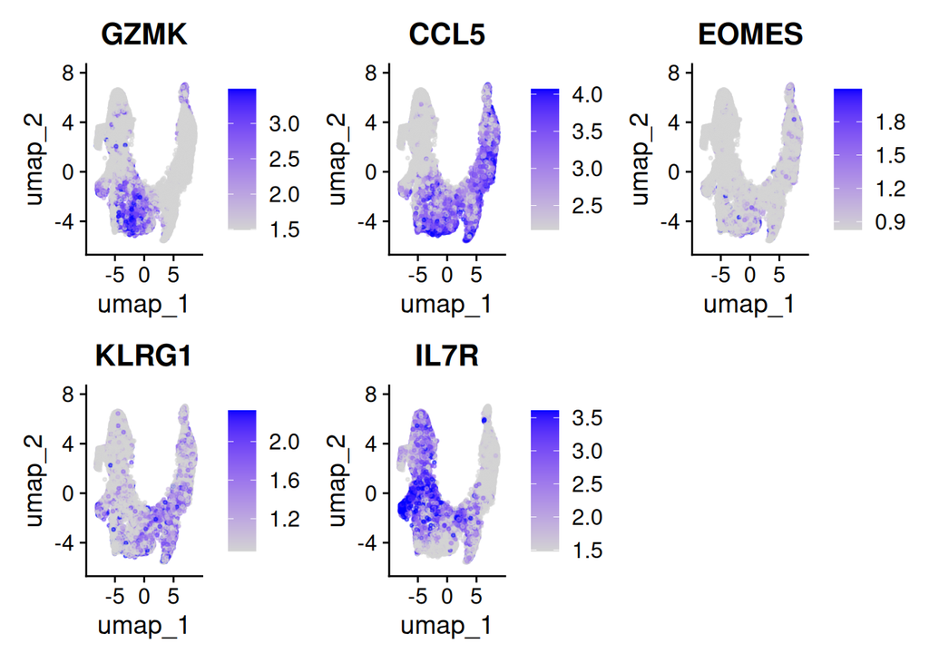

```r
FeaturePlot(
  seurat_object, reduction = "umap", ncol = 3,
  min.cutoff = min_cutoff, max.cutoff = max_cutoff,
  features = c("GZMK", "CCL5", "EOMES", "KLRG1", "IL7R"),
  pt.size = pt_size, alpha = alpha, raster = raster, raster.dpi = raster_dpi
)
```

```r
ggsave(file.path(res_path, "05_markers_Tem.pdf"), width = 18, height = 10)
```

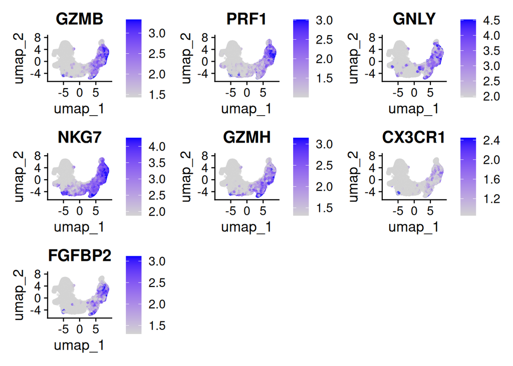

```r
FeaturePlot(
  seurat_object, reduction = "umap", ncol = 3,
  min.cutoff = min_cutoff, max.cutoff = max_cutoff,
  features = c("GZMB", "PRF1", "GNLY", "NKG7", "GZMH", "CX3CR1", "FGFBP2"),
  pt.size = pt_size, alpha = alpha, raster = raster, raster.dpi = raster_dpi
)
```

```r
ggsave(file.path(res_path, "05_markers_CTL.pdf"), width = 18, height = 15)
```

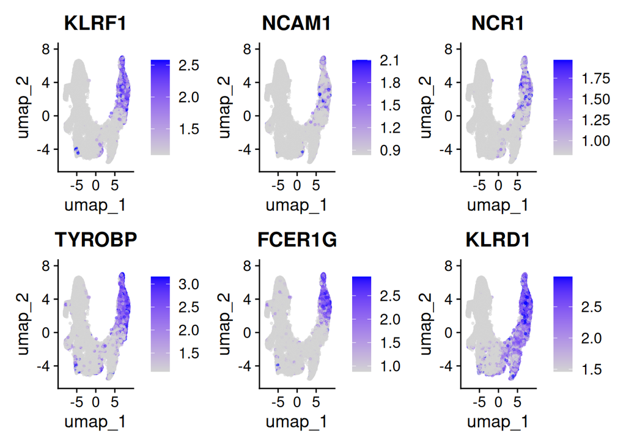

```r
FeaturePlot(
  seurat_object, reduction = "umap", ncol = 3,
  min.cutoff = min_cutoff, max.cutoff = max_cutoff,
  features = c("KLRF1", "NCAM1", "NCR1", "TYROBP", "FCER1G", "KLRD1"),
  pt.size = pt_size, alpha = alpha, raster = raster, raster.dpi = raster_dpi
)
```

```r
ggsave(file.path(res_path, "05_markers_NK.pdf"), width = 18, height = 10)
```

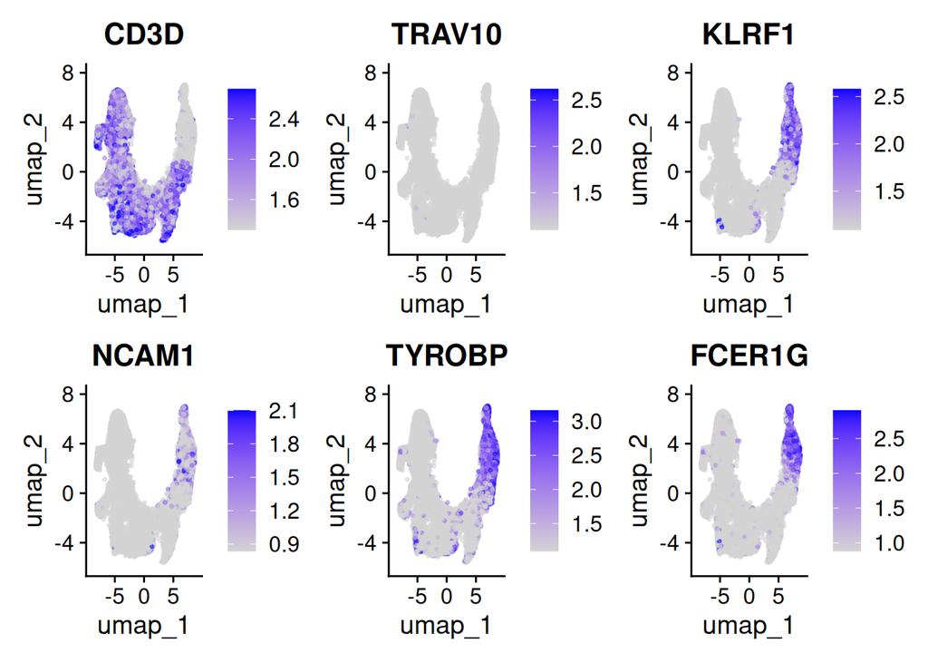

```r
FeaturePlot(
  seurat_object, reduction = "umap", ncol = 3,
  min.cutoff = min_cutoff, max.cutoff = max_cutoff,
  features = c("CD3D", "TRAV10", "KLRF1", "NCAM1", "TYROBP", "FCER1G"),
  pt.size = pt_size, alpha = alpha, raster = raster, raster.dpi = raster_dpi
)
```

```r
ggsave(file.path(res_path, "05_markers_NKT.pdf"), width = 18, height = 10)
```

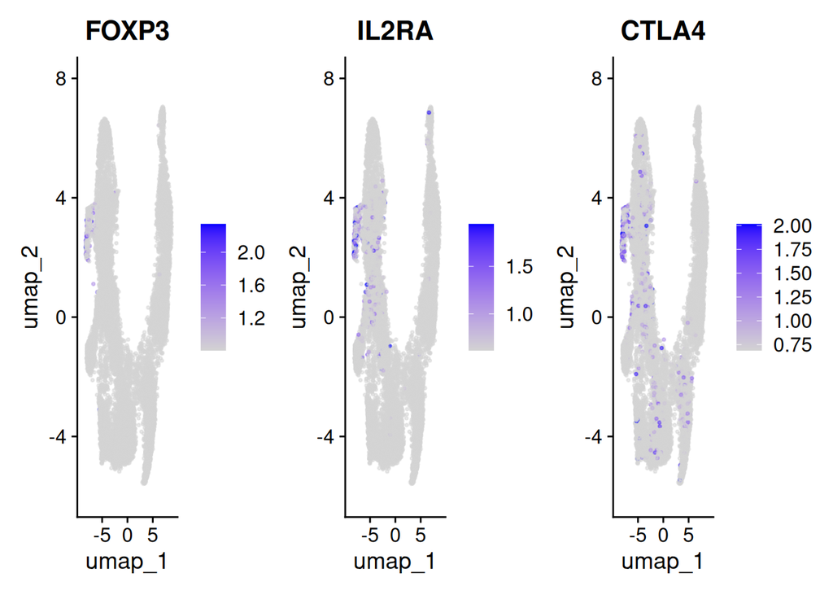

```r
FeaturePlot(
  seurat_object, reduction = "umap", ncol = 3,
  min.cutoff = min_cutoff, max.cutoff = max_cutoff,
  features = c("FOXP3", "IL2RA", "CTLA4"),
  pt.size = pt_size, alpha = alpha, raster = raster, raster.dpi = raster_dpi
)
```

```r
ggsave(file.path(res_path, "05_markers_Treg.pdf"), width = 18, height = 5)
```

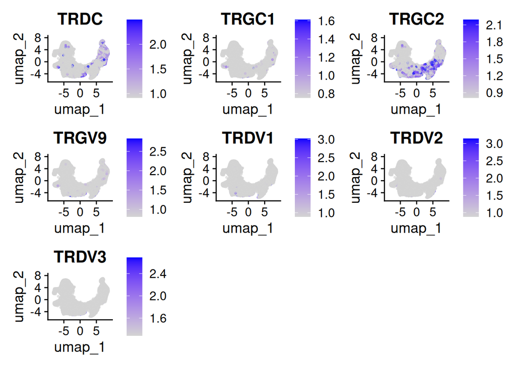

```r
FeaturePlot(
  seurat_object, reduction = "umap", ncol = 3,
  min.cutoff = min_cutoff, max.cutoff = max_cutoff,
  features = c("TRDC", "TRGC1", "TRGC2", "TRGV9", "TRDV1", "TRDV2", "TRDV3"),
  pt.size = pt_size, alpha = alpha, raster = raster, raster.dpi = raster_dpi
)
```

```r
ggsave(file.path(res_path, "05_markers_gdT.pdf"), width = 18, height = 15)
```

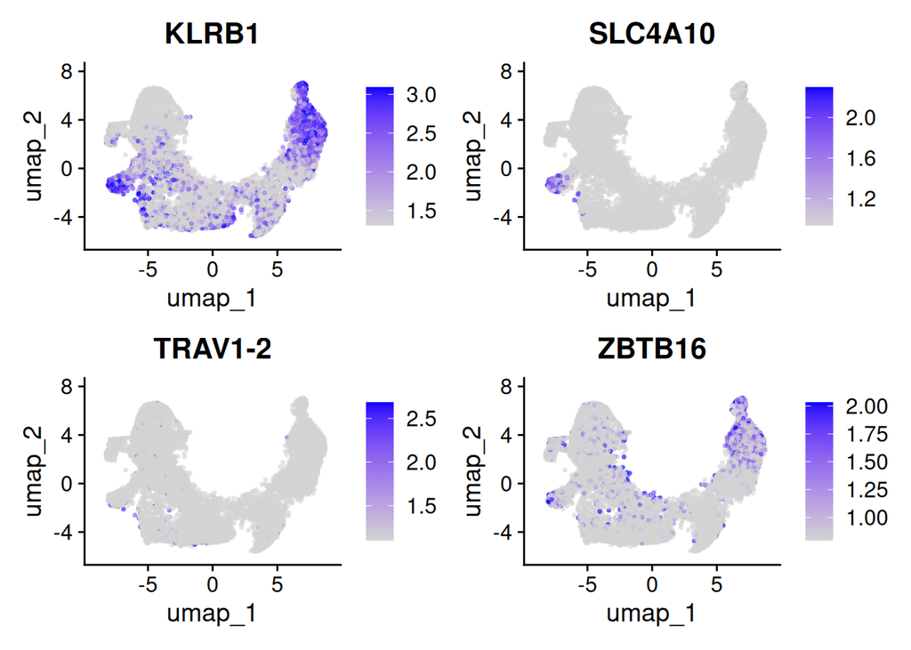

```r
FeaturePlot(
  seurat_object, reduction = "umap", ncol = 2,
  min.cutoff = min_cutoff, max.cutoff = max_cutoff,
  features = c("KLRB1", "SLC4A10", "TRAV1-2", "ZBTB16"),
  pt.size = pt_size, alpha = alpha, raster = raster, raster.dpi = raster_dpi
)
```

```r
ggsave(file.path(res_path, "05_markers_MAIT.pdf"), width = 12, height = 10)
```

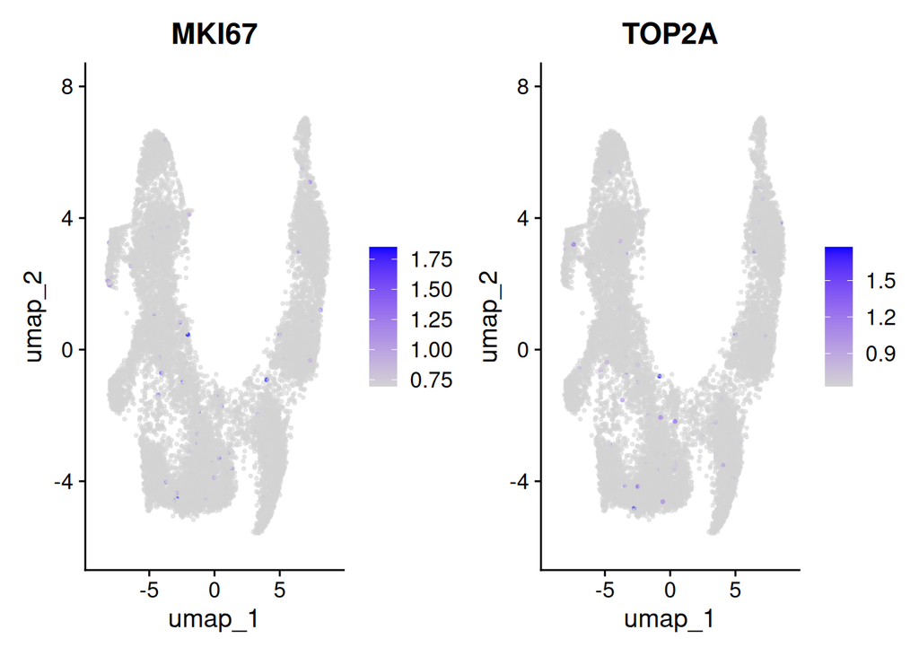

```r
FeaturePlot(
  seurat_object, reduction = "umap", ncol = 2,
  min.cutoff = min_cutoff, max.cutoff = max_cutoff,
  features = c("MKI67", "TOP2A"),
  pt.size = pt_size, alpha = alpha, raster = raster, raster.dpi = raster_dpi
)
```

```r
ggsave(file.path(res_path, "05_markers_cycling.pdf"), width = 18, height = 5)
```

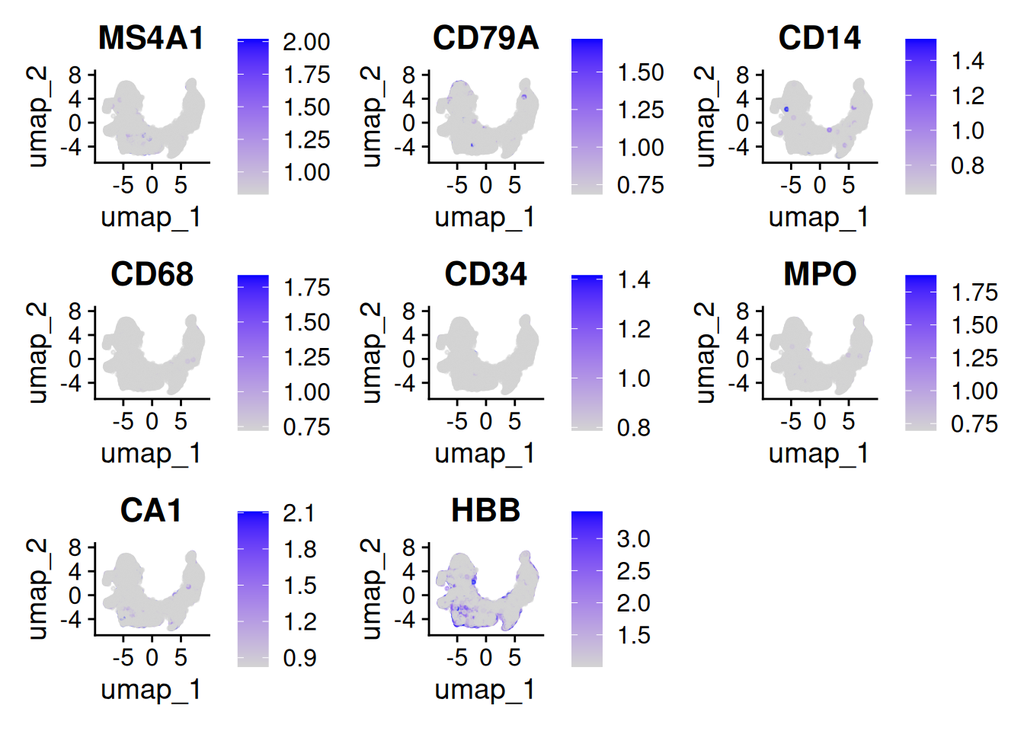

```r
FeaturePlot(
  seurat_object, reduction = "umap", ncol = 3,
  min.cutoff = min_cutoff, max.cutoff = max_cutoff,
  features = c("MS4A1", "CD79A", "CD14", "CD68", "CD34", "MPO", "CA1", "HBB"),
  pt.size = pt_size, alpha = alpha, raster = raster, raster.dpi = raster_dpi
)
```

```r
ggsave(file.path(res_path, "05_markers_contam.pdf"), width = 18, height = 15)
```